# Effect of hatching condition on gene expression

J. Ignacio Lucas Lledó

# Model 1

Model 1 is expected to be the most sensitive to detect genes the expression of which is affected by enforcing diapause, after accounting for the variation among populations (which includes variation due to selective regime).

```r
qlf1 <- glmQLFTest(fit1)
topTags(qlf1)
```

```
## Coefficient:  diapausediapause
##                 logFC      logCPM        F       PValue       FDR
## XLOC_052427 -2.862577 -0.03880226 74.25517 1.248169e-05 0.2308739
## XLOC_045087 -2.092068 -0.62193946 61.97451 2.574843e-05 0.2381344
## XLOC_046298 -2.137567  2.03533181 47.20612 7.444936e-05 0.4079983
## XLOC_044305 -1.793393  0.74051195 42.36960 1.122658e-04 0.4079983
## XLOC_039886 -1.073438  3.55924117 39.75017 1.426172e-04 0.4079983
## XLOC_031542 -1.315396  3.43871982 37.38349 1.791055e-04 0.4079983
## XLOC_039932 -2.229434  0.57344448 37.22741 1.818926e-04 0.4079983
## XLOC_008112 -1.069522  3.44918221 36.21625 2.012926e-04 0.4079983
## XLOC_005549 -1.399274  0.90839738 35.58890 2.146081e-04 0.4079983
## XLOC_027320 -2.327739 -1.25310508 34.57151 2.385751e-04 0.4079983
```

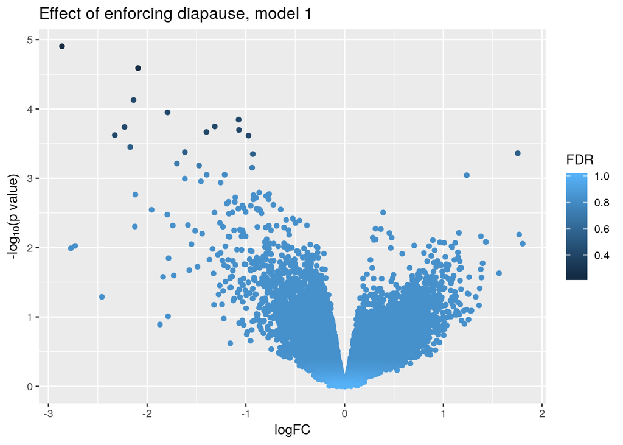

```r
z1 <- topTags(qlf1, n=NumOfTags)$table
z1$logPValue <- -log10(z1$PValue)
ggplot(data=z1, mapping=aes(x=logFC, y=logPValue, color=FDR)) +
   geom_point() + theme_grey() + ylab(expression(paste("-log"[10], plain("(p value)")))) +
   ggtitle('Effect of enforcing diapause, model 1')
```

I would say the two first genes (XLOC_052427 and XLOC_045087) are significantly downregulated when enforcing diapause, with respect to the immediate hatching condition. Below, I print to a file the whole list of genes (or transcripts) for a functional enrichment analysis:

```r
write.table(topTags(qlf1, n=NumOfTags), file=sprintf("%s/hatching.txt", args[2]), quote=FALSE)
```

# Model 2

Model 2 is very simple, and may include false positives, because it does not account for any interaction, nor for among-population variance.

```r
qlf2 <- glmQLFTest(fit2, coef=3)
topTags(qlf2)
```

```
## Coefficient:  diapausediapause
##                  logFC      logCPM        F       PValue       FDR
## XLOC_046298 -2.1934422  2.03326110 51.93989 7.891698e-06 0.0570513
## XLOC_045087 -2.0997097 -0.62715097 51.05617 8.624217e-06 0.0570513
## XLOC_052427 -2.8514007 -0.04558558 50.36423 9.253063e-06 0.0570513
## XLOC_039932 -2.2421986  0.56806964 39.82751 3.016192e-05 0.1394763
## XLOC_005549 -1.4557679  0.90508954 33.88444 6.573878e-05 0.1864978
## XLOC_011476 -0.9558098  2.80761818 33.59469 6.846023e-05 0.1864978
## XLOC_031542 -1.3570219  3.43794075 33.35405 7.081991e-05 0.1864978
## XLOC_027320 -2.2743372 -1.25974811 32.44203 8.066079e-05 0.1864978
## XLOC_044305 -1.7886843  0.73658501 30.90979 1.009973e-04 0.2039456
## XLOC_039925 -2.2624738 -0.39613265 30.32658 1.102588e-04 0.2039456
```

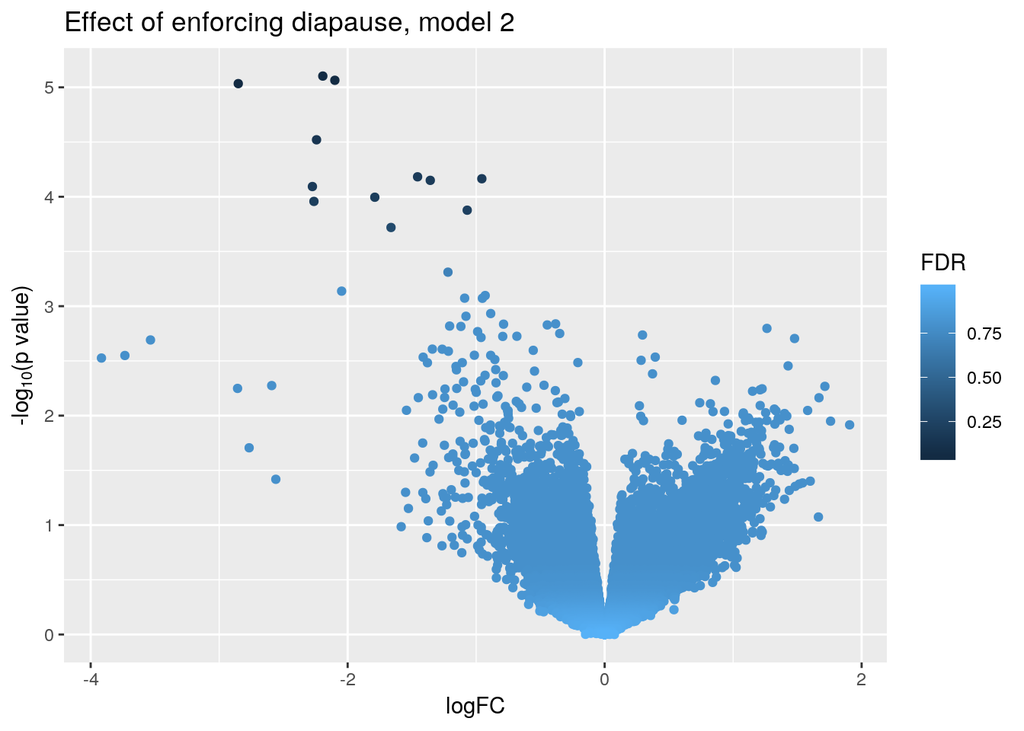

```r
z1 <- topTags(qlf2, n=NumOfTags)$table
z1$logPValue <- -log10(z1$PValue)
ggplot(data=z1, mapping=aes(x=logFC, y=logPValue, color=FDR)) +
   geom_point() + theme_grey() + ylab(expression(paste("-log"[10], plain("(p value)")))) +
   ggtitle('Effect of enforcing diapause, model 2')
```

According to model 2, there are 3 tags significantly up- or downregulated by hatching condition, at FDR=0.1.

# Model 3

In model 3, the effect of diapause may be understood in two different ways. First, we may want to know what genes have an average expression level different between hatching conditions. This is different from testing the effect of hatching condition twice: first among samples in a regular environment and then among those in the stochastic environment. Then, I could select the genes with the same significant tendency in both selective regimes. I will start this analysis to the first option, comparing only average gene expression level.

```r
qlf3 <- glmQLFTest(fit3, contrast=c(-0.5, 0.5, -0.5, 0.5))
topTags(qlf3)
```

```
## Coefficient:  -0.5*combinedRegulHatch 0.5*combinedRandDiap -0.5*combinedRandHatch 0.5*combinedRegulDiap
##                 logFC      logCPM        F       PValue       FDR
## XLOC_039932 -2.416741  0.56620035 51.59509 1.359728e-05 0.1183499
## XLOC_045087 -2.165847 -0.62906850 49.75699 1.617579e-05 0.1183499
## XLOC_046298 -2.190837  2.03257170 46.84209 2.154356e-05 0.1183499
## XLOC_052427 -2.877561 -0.04800235 45.15838 2.559331e-05 0.1183499
## XLOC_005549 -1.471140  0.90395245 31.56960 1.291712e-04 0.4091716
## XLOC_031542 -1.358202  3.43768730 30.44766 1.510495e-04 0.4091716
## XLOC_011476 -0.956062  2.80722007 30.27242 1.548468e-04 0.4091716
## XLOC_039925 -2.376220 -0.39740095 29.11401 1.829706e-04 0.4199041
## XLOC_044305 -1.793839  0.73522984 27.89970 2.191245e-04 0.4199041
## XLOC_027320 -2.212433 -1.26225398 27.66599 2.270120e-04 0.4199041
```

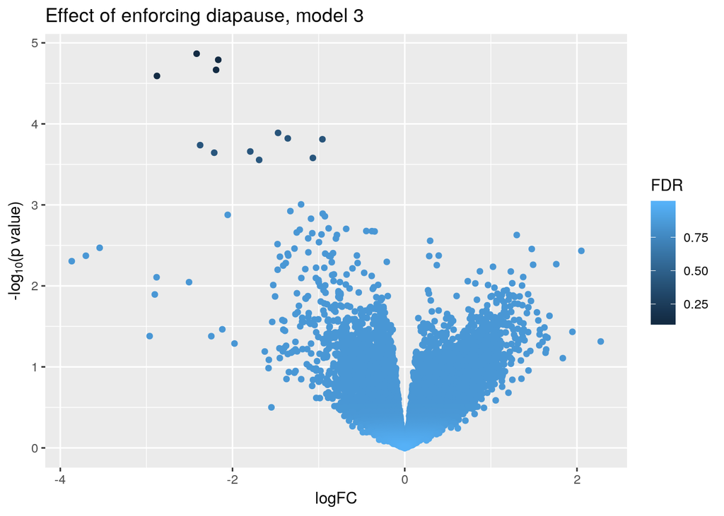

```r
z1 <- topTags(qlf3, n=NumOfTags)$table
z1$logPValue <- -log10(z1$PValue)
ggplot(data=z1, mapping=aes(x=logFC, y=logPValue, color=FDR)) +
   geom_point() + theme_grey() + ylab(expression(paste("-log"[10], plain("(p value)")))) +
   ggtitle('Effect of enforcing diapause, model 3')
```

According to model 3, there are 0 tags significantly up- or downregulated by hatching condition at FDR = 0.1.

For the sake of comparing model 3 to the results from Cuffdiff, I will make each one of the four possible comparisons, if analysing genes. The four coefficients of model correspond, in this order, to: regular regime and immediate hatching, random regime and diapause, random regime and hatching, and regular regime and diapause. In Eva’s terms, I believe they correspond to P1, I2, I1, and P2. However, Cuffdiff was not run on isoforms, but only genes.

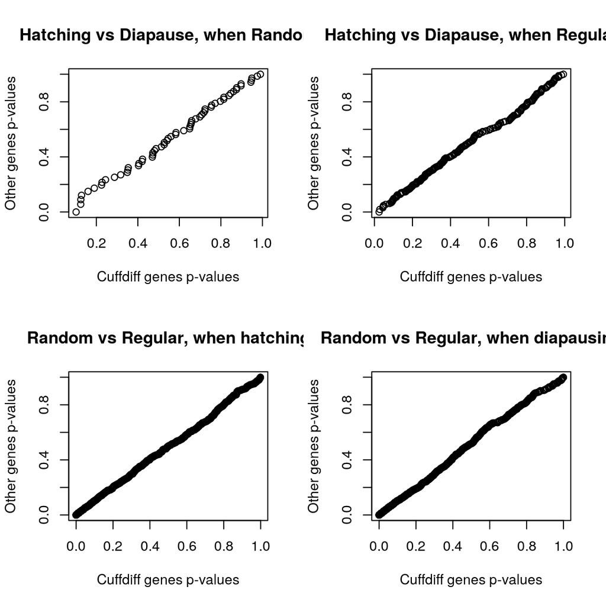

```r
if (grepl('genes', input_file_name)) {
   #                                     P1 I2 I1 P2
   qlf3_1 <- glmQLFTest(fit3, contrast=c( 0,-1, 1, 0)) # I1vsI2
   qlf3_2 <- glmQLFTest(fit3, contrast=c( 1, 0, 0,-1)) # P1vsP2
   qlf3_3 <- glmQLFTest(fit3, contrast=c(-1, 0, 1, 0)) # I1vsP1
   qlf3_4 <- glmQLFTest(fit3, contrast=c( 0, 1, 0,-1)) # I2vsP2

   z1 <- topTags(qlf3_1, n=NumOfTags)$table
   z2 <- topTags(qlf3_2, n=NumOfTags)$table
   z3 <- topTags(qlf3_3, n=NumOfTags)$table
   z4 <- topTags(qlf3_4, n=NumOfTags)$table

   z1$inCuffdiff <- row.names(z1) %in% I1vsI2$geneid
   z2$inCuffdiff <- row.names(z2) %in% P1vsP2$geneid
   z3$inCuffdiff <- row.names(z3) %in% I1vsP1$geneid
   z4$inCuffdiff <- row.names(z4) %in% I2vsP2$geneid

   layout(mat=matrix(c(1,2,3,4), ncol=2, nrow=2, byrow=TRUE))
   qqplot(z1$PValue[z1$inCuffdiff], z1$PValue[!z1$inCuffdiff], xlab='Cuffdiff genes p-values', ylab='Other genes p-values', main='Hatching vs Diapause, when Random')
   qqplot(z2$PValue[z2$inCuffdiff], z2$PValue[!z2$inCuffdiff], xlab='Cuffdiff genes p-values', ylab='Other genes p-values', main='Hatching vs Diapause, when Regular')
   qqplot(z3$PValue[z3$inCuffdiff], z3$PValue[!z3$inCuffdiff], xlab='Cuffdiff genes p-values', ylab='Other genes p-values', main='Random vs Regular, when hatching')
   qqplot(z4$PValue[z4$inCuffdiff], z4$PValue[!z4$inCuffdiff], xlab='Cuffdiff genes p-values', ylab='Other genes p-values', main='Random vs Regular, when diapausing')
}
```

If analysing genes, the graphs above compare the distribution of p-values of genes called differentially regulated by Cuffdiff with the distribution of p-values among the rest of genes. It can be seen that in all comparisons, the genes detected as differentially expressed by Cuffdiff are not assigned lower p-values by EdgeR in the same comparisons. Rather, they look random samples of genes with respect to their p-values.

# Model 4

```r
qlf4 <- glmQLFTest(fit4, coef=3)
topTags(qlf4)
```

```
## Coefficient:  diapausediapause
##                 logFC      logCPM        F       PValue       FDR
## XLOC_052427 -2.862577 -0.03880226 74.25517 1.248169e-05 0.2308739
## XLOC_045087 -2.092068 -0.62193946 61.97451 2.574843e-05 0.2381344
## XLOC_046298 -2.137567  2.03533181 47.20612 7.444936e-05 0.4079984
## XLOC_044305 -1.793393  0.74051195 42.36960 1.122658e-04 0.4079984
## XLOC_039886 -1.073438  3.55924117 39.75017 1.426172e-04 0.4079984
## XLOC_031542 -1.315396  3.43871982 37.38349 1.791055e-04 0.4079984
## XLOC_039932 -2.229434  0.57344448 37.22741 1.818926e-04 0.4079984
## XLOC_008112 -1.069522  3.44918221 36.21625 2.012926e-04 0.4079984
## XLOC_005549 -1.399274  0.90839738 35.58890 2.146081e-04 0.4079984
## XLOC_027320 -2.327739 -1.25310508 34.57151 2.385751e-04 0.4079984
```

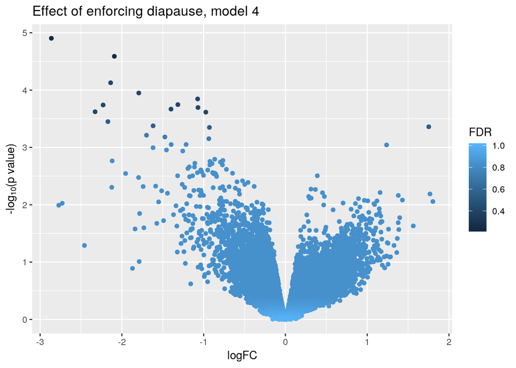

```r
z1 <- topTags(qlf4, n=NumOfTags)$table
z1$logPValue <- -log10(z1$PValue)
ggplot(data=z1, mapping=aes(x=logFC, y=logPValue, color=FDR)) +
   geom_point() + theme_grey() + ylab(expression(paste("-log"[10], plain("(p value)")))) +
   ggtitle('Effect of enforcing diapause, model 4')
```

According to model 4, there are 0 tags significantly up- or downregulated by hatching condition at FDR = 0.1.

# Model 5

```r
qlf5 <- glmQLFTest(fit5, coef=3)
topTags(qlf5)
```

```
## Coefficient:  diapausediapause
##                  logFC      logCPM        F       PValue       FDR
## XLOC_046298 -2.2208975  2.03257170 25.66097 0.0003103538 0.8615771
## XLOC_052427 -2.7733434 -0.04800235 25.29651 0.0003291244 0.8615771
## XLOC_045087 -1.9059084 -0.62906850 24.01320 0.0004067258 0.8615771
## XLOC_027320 -2.4408746 -1.26225398 20.86498 0.0007086469 0.8615771
## XLOC_039932 -1.7647818  0.56620035 17.70824 0.0013133786 0.8615771
## XLOC_039886 -1.1543798  3.55817365 16.00059 0.0018901224 0.8615771
## XLOC_011476 -0.9436807  2.80722007 15.14173 0.0022910345 0.8615771
## XLOC_039925 -2.0596861 -0.39740095 14.97445 0.0023803449 0.8615771
## XLOC_005549 -1.3491437  0.90395245 14.83294 0.0024591126 0.8615771
## XLOC_051241  0.7232360  4.03455535 14.53545 0.0026349465 0.8615771
```

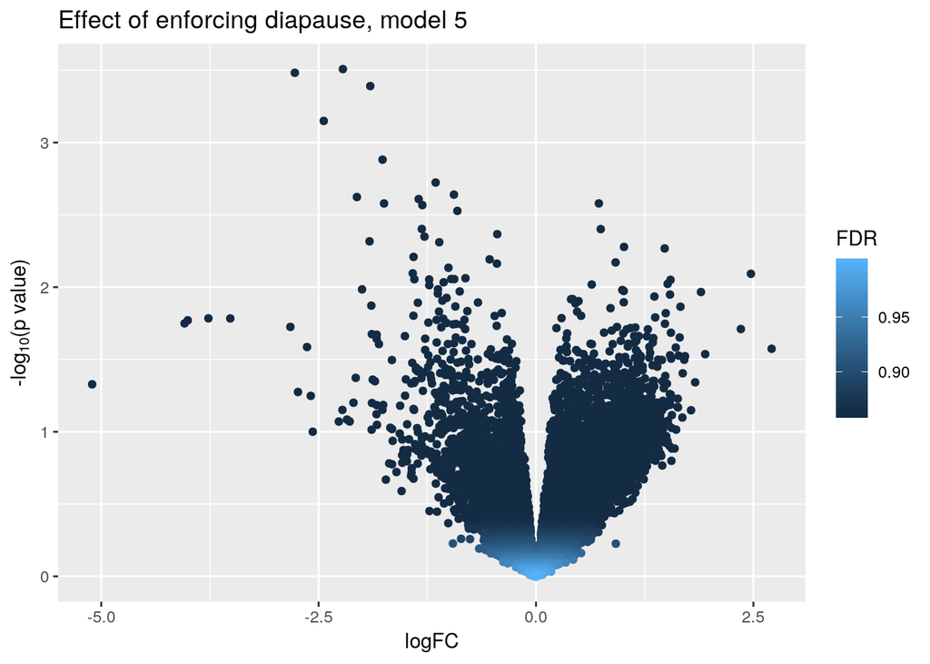

```r
z1 <- topTags(qlf5, n=NumOfTags)$table
z1$logPValue <- -log10(z1$PValue)
ggplot(data=z1, mapping=aes(x=logFC, y=logPValue, color=FDR)) +
   geom_point() + theme_grey() + ylab(expression(paste("-log"[10], plain("(p value)")))) +
   ggtitle('Effect of enforcing diapause, model 5')
```

According to model 5, there are 0 tags significantly up- or downregulated by hatching condition at FDR = 0.1.

# Model 6

```r
qlf6 <- glmQLFTest(fit6, coef=3)
topTags(qlf6)
```

```
## Coefficient:  diapausediapause
##                 logFC      logCPM        F       PValue       FDR
## XLOC_052427 -2.782851 -0.04348303 36.74881 0.0003507945 0.8762488
## XLOC_045087 -1.904357 -0.62550917 30.14265 0.0006612656 0.8762488
## XLOC_046298 -2.149860  2.03388091 22.12908 0.0016986145 0.8762488
## XLOC_050455  1.911918 -1.73035181 21.72935 0.0017924047 0.8762488
## XLOC_027320 -2.492942 -1.25762929 21.65528 0.0018104944 0.8762488
## XLOC_018887 -1.023882  2.41333434 20.97668 0.0019874586 0.8762488
## XLOC_039886 -1.154353  3.55867346 20.66676 0.0020755324 0.8762488
## XLOC_044305 -1.749829  0.73778255 19.20150 0.0025655416 0.8762488
## XLOC_017314 -1.507200  1.67498895 17.65544 0.0032523479 0.8762488
## XLOC_053013 -1.890138 -1.60856602 17.64418 0.0032581490 0.8762488
```

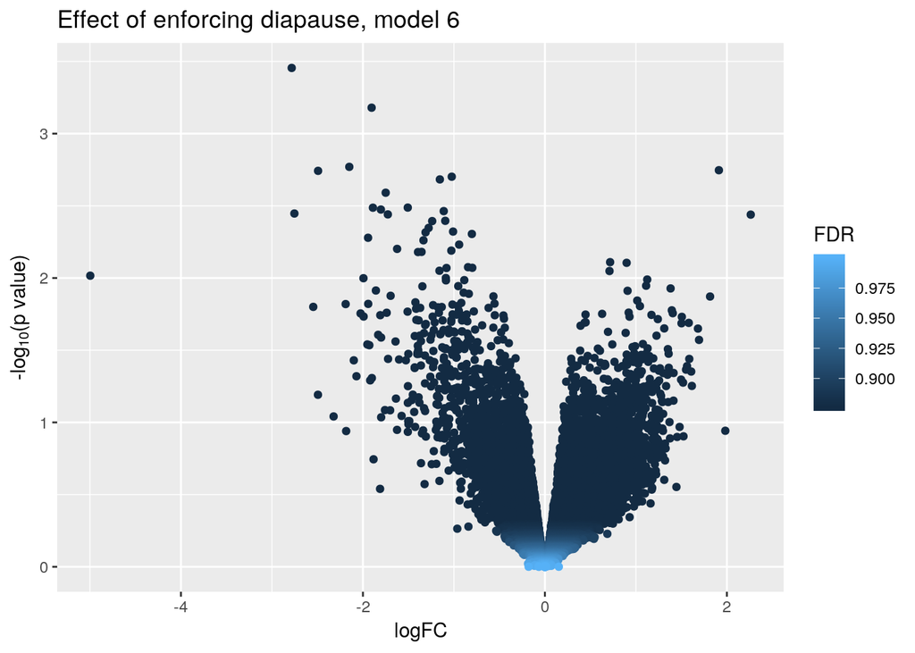

```r
z1 <- topTags(qlf6, n=NumOfTags)$table
z1$logPValue <- -log10(z1$PValue)
ggplot(data=z1, mapping=aes(x=logFC, y=logPValue, color=FDR)) +
   geom_point() + theme_grey() + ylab(expression(paste("-log"[10], plain("(p value)")))) +
   ggtitle('Effect of enforcing diapause, model 6')
```

According to model 6, there are 0 tags significantly up- or downregulated by hatching condition at FDR = 0.10. And this is how the results from models 1, 2, 3 and 4 match:

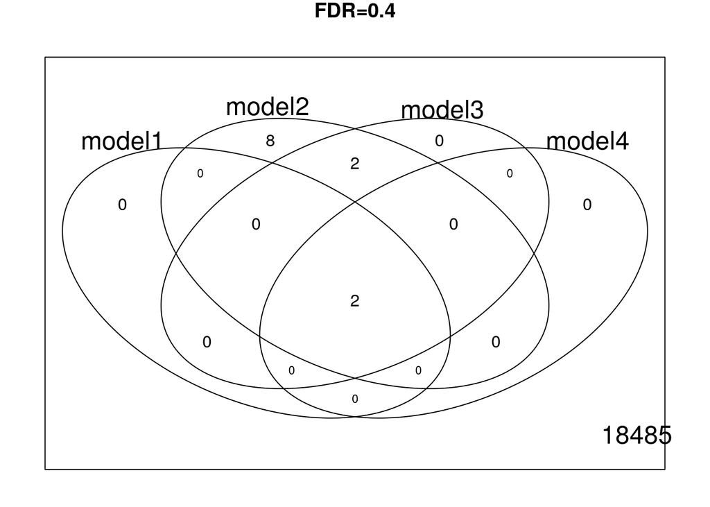

```r
significant <- cbind(model1 = topTags(qlf1, n=NumOfTags, sort.by='none')$table$FDR <= 0.4,
                     model2 = topTags(qlf2, n=NumOfTags, sort.by='none')$table$FDR <= 0.4,
                     model3 = topTags(qlf3, n=NumOfTags, sort.by='none')$table$FDR <= 0.4,
                     model4 = topTags(qlf4, n=NumOfTags, sort.by='none')$table$FDR <= 0.4)
vennDiagram(vennCounts(significant), main='FDR=0.4')
```

The genes detected at FDR < 0.4 by models 1, 2 are XLOC_052427, XLOC_045087 . No need for a functional enrichment analysis.